# Network Science Project: Darkweb Dataset

Diego Cirillo 157176

2025-01-01

# Introduzione

## Contesto del Dataset

Il dataset analizzato in questo progetto rappresenta uno snapshot della sottorete “darkweb” del World Wide Web, ottenuto tramite crawling attraverso il popolare proxy tor2web `onion.link`. In questa rete, ogni nodo corrisponde a un dominio, mentre un arco pesato tra due nodi rappresenta il numero di pagine su un dominio che contengono link verso un altro dominio. Il dataset copre un intervallo temporale compreso tra novembre 2016 e febbraio 2017.

## Obiettivi dell’Analisi

L’obiettivo di questa analisi è esplorare la struttura del darkweb utilizzando tecniche di Network Science. In particolare, mi concentrerò su:

- **Analisi locale**: studio delle proprietà dei singoli nodi, come il grado, la centralità e la distribuzione dei link.
- **Analisi di gruppo**: individuazione di comunità e cluster all’interno della rete, utilizzando algoritmi di clustering.
- **Analisi globale**: valutazione delle caratteristiche strutturali della rete, tra cui connettività, distribuzione dei gradi e proprietà di small-world.

Questa analisi fornirà spunti utili per comprendere la connettività e l’organizzazione della darkweb, mettendo in evidenza eventuali nodi centrali e strutture emergenti.

# Caricamento dati

```r
edges <- read.csv("data/darkweb-edges.ss", sep = ";")
nodes <- read.csv("data/darkweb-nodes.ss", sep = ";")
```

```r
head(edges)
```

```
##             Source           Target     Type Weight
## 1 visitorfi5kl7q7i uisspxbl7ipc5bet Directed      1
## 2 visitorfi5kl7q7i xidp5a5k3rlxr5r3 Directed      1
## 3 visitorfi5kl7q7i 7uvijlsswycvih2p Directed      1
## 4 visitorfi5kl7q7i 4oy7nsv57l3ragqz Directed      1
## 5 visitorfi5kl7q7i prometh5th5t5rfd Directed      1
## 6 visitorfi5kl7q7i bdpuqvl2ksq2vzs3 Directed      1
```

```r
head(nodes)
```

```
##                 Id Label
## 1 visitorfi5kl7q7i    NA
## 2 uisspxbl7ipc5bet    NA
## 3 directoryvi6plzm    NA
## 4 telnetg42y5crrb7    NA
## 5 gl75awtvsmp2ofe6    NA
## 6 gxamjbnu7uknahng    NA
```

# Analisi preliminare degli archi

Prima di iniziare con le vere analisi controllo i dati presenti nel dataset.

## Numero di archi e di nodi

```r
num_nodes <- nrow(nodes)
num_edges <- nrow(edges)
cat("La rete analizzata è composta da", num_nodes, "nodi e", num_edges, "archi\n")
```

```
## La rete analizzata è composta da 7178 nodi e 25104 archi
```

L’analisi suggerisce una rete complessa con un numero significativo di connessioni.

## Piccola analisi sugli archi

Ho iniziato verificando alcune proprietà degli archi della rete:

### Archi con peso maggiore di 1

```r
heavy_weights <- edges %>%
  filter(Weight > 1)

cat("Sono stati rilevati", nrow(heavy_weights) ,"archi con peso superiore a 1\n")
```

```
## Sono stati rilevati 17091 archi con peso superiore a 1
```

```r
head(heavy_weights)
```

```
##             Source           Target     Type Weight
## 1 visitorfi5kl7q7i ak2uqfavwgmjrvtu Directed      2
## 2 visitorfi5kl7q7i gunsjmzh2btr7lpy Directed      2
## 3 visitorfi5kl7q7i 4iahqcjrtmxwofr6 Directed      2
## 4 visitorfi5kl7q7i torbox3uiot6wchz Directed      2
## 5 visitorfi5kl7q7i rf3xojfkckdumtvj Directed      2
## 6 visitorfi5kl7q7i torbox3gurtwq5tz Directed      2
```

### Archi indiretti

In ogni arco c’è un campo “Type” che determina se è diretto o non diretto, controllo se ci sono effettivamente archi non diretti.

```r
undirected_edges <- edges %>%
  filter(Type != "Directed")

cat("Sono stati rilevati", nrow(undirected_edges) ,"archi indiretti\n")
```

```
## Sono stati rilevati 0 archi indiretti
```

### Self loops

```r
# Filter self-loops (Source == Target)
self_loops <- edges %>%
  filter(Source == Target)

cat("Sono stati rilevati", nrow(self_loops), "self loops\n")
```

```
## Sono stati rilevati 0 self loops
```

Strano non ci siano nodi con self loops, probabilmente sono stati rimossi dal creatore del dataset o il crawler che è stato usato eliminava in automatico i link allo stesso dominio della pagina.

# Creazione grafo

```r
g <- tbl_graph(nodes = nodes, edges = edges, directed = TRUE)

head(as_tibble(g, "nodes"))
```

```
## # A tibble: 6 × 2
##   Id               Label
##   <chr>            <lgl>
## 1 visitorfi5kl7q7i NA
## 2 uisspxbl7ipc5bet NA
## 3 directoryvi6plzm NA
## 4 telnetg42y5crrb7 NA
## 5 gl75awtvsmp2ofe6 NA
## 6 gxamjbnu7uknahng NA
```

```r
head(as_tibble(g, "edges"))
```

```
## # A tibble: 6 × 4
##    from    to Type     Weight
##   <int> <int> <chr>     <int>
## 1     1     2 Directed      1
## 2     1     8 Directed      1
## 3     1    16 Directed      1
## 4     1    21 Directed      1
## 5     1    25 Directed      1
## 6     1    29 Directed      1
```

# Visualizzazione del grafo

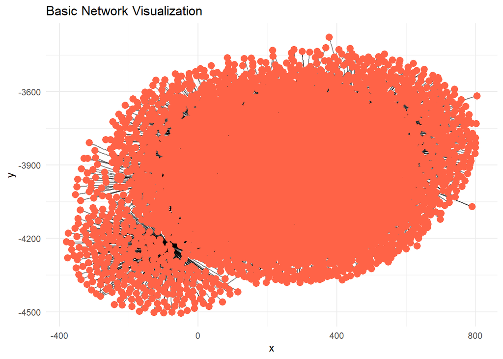

```r
ggraph(g, layout = "lgl") +
  geom_edge_link(alpha = 0.5) +
  geom_node_point(size = 3, color = "tomato") +
  theme_minimal() +
  labs(title = "Basic Network Visualization")
```

La rete appare densa, con un alto numero di nodi e connessioni, formando una struttura ellittica con un nucleo centrale fortemente connesso e nodi periferici meno collegati. L’assenza di nodi isolati suggerisce un’alta connettività complessiva. La distribuzione delle connessioni potrebbe indicare una rete scale-free, con pochi hub altamente connessi e molti nodi con poche connessioni.

# Local Analysis

```r
g <- g %>%
  activate(nodes) %>%
  mutate(
    in_degree = centrality_degree(mode = "in"),
    out_degree = centrality_degree(mode = "out"),
    betweenness = centrality_betweenness(),
    closeness = centrality_closeness(),
    eigen = centrality_eigen(),
    pagerank = centrality_pagerank(),
  )
```

## Distribuzione del grado

```r
node_data <- as_tibble(g)

skewness = function(x) mean( (x - mean(x))^3 ) / sd(x)^3
cat("skewness in-degree:", skewness(node_data$in_degree), "\n")
```

```
## skewness in-degree: 13.82088
```

```r
cat("skewness out-degree:", skewness(node_data$out_degree), "\n")
```

```
## skewness out-degree: 45.83592
```

```r
summary(node_data$in_degree)
```

```
##    Min. 1st Qu.  Median    Mean 3rd Qu.    Max.
##   1.000   2.000   3.000   3.497   4.000 209.000
```

```r
summary(node_data$out_degree)
```

```
##     Min.  1st Qu.   Median     Mean  3rd Qu.     Max.
##    0.000    0.000    0.000    3.497    0.000 5582.000
```

```r
zero_out_degree <- as_tibble(g, what = "nodes") %>%
  filter(out_degree == 0)

cat(nrow(zero_out_degree), "nodi hanno 0 archi uscenti su", nrow(nodes), "\n")
```

```
## 6242 nodi hanno 0 archi uscenti su 7178
```

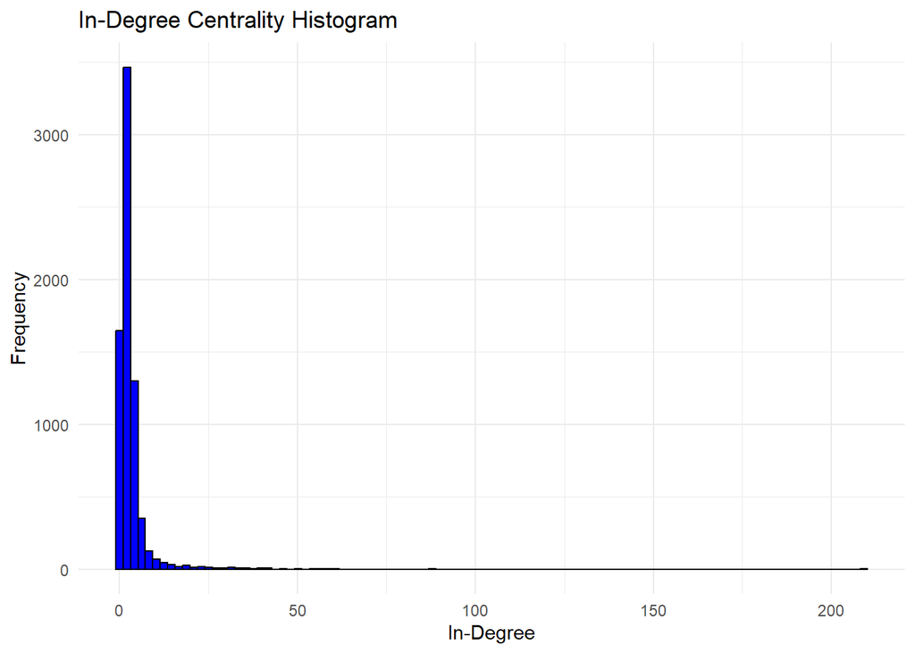

```r
ggplot(node_data, aes(x = in_degree)) +
  geom_histogram(binwidth = max(node_data$in_degree) / 100, fill = "blue", color = "black") +
  labs(title = "In-Degree Centrality Histogram",
       x = "In-Degree",
       y = "Frequency") +
  theme_minimal()
```

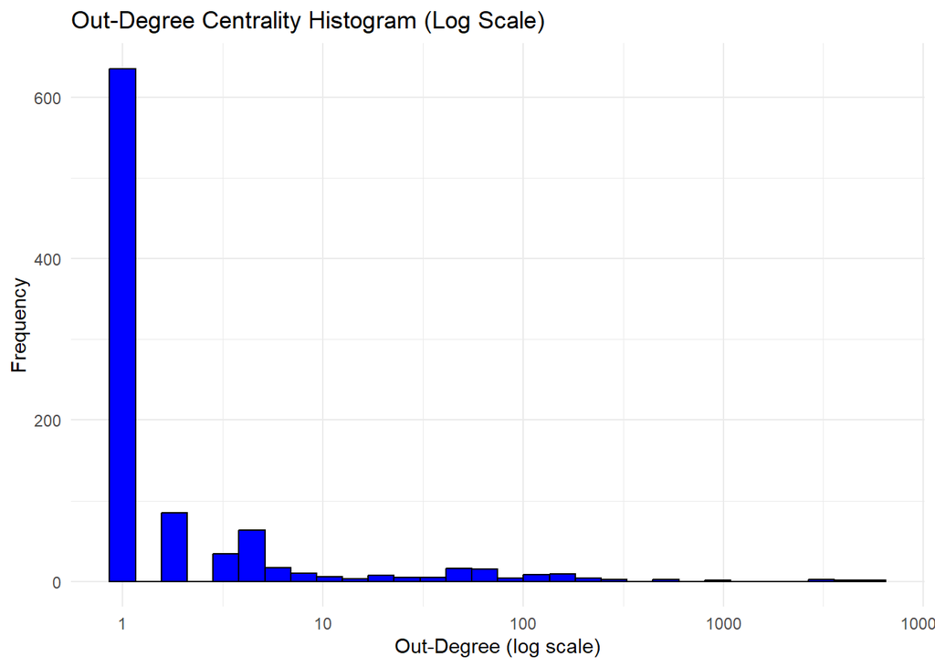

```r
ggplot(node_data, aes(x = out_degree)) +
  geom_histogram(bins = 30, fill = "blue", color = "black") +
  scale_x_log10() +  # Log-transform the x-axis
  labs(title = "Out-Degree Centrality Histogram (Log Scale)",
       x = "Out-Degree (log scale)",
       y = "Frequency") +
  theme_minimal()
```

La distribuzione del grado mostra una rete altamente sbilanciata, con la maggior parte dei nodi che possiede pochi collegamenti in uscita, mentre un numero ristretto di nodi ha un numero estremamente elevato di connessioni. Questo aumenta la supposizione di una struttura scale-free, dove pochi nodi fungono da hub con un ruolo centrale nella diffusione dell’informazione, mentre la maggior parte dei nodi ha un’influenza limitata sulla rete.

## Verifica della legge di potenza

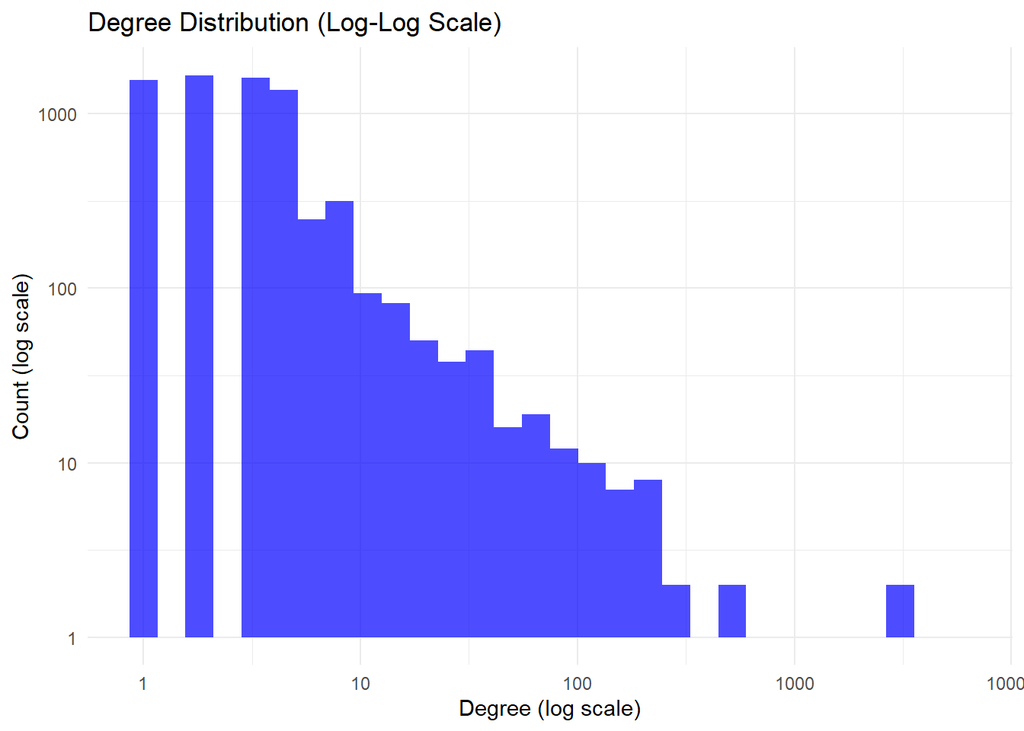

```r
degree_dist = degree(g, mode = "all")
degree_df = data.frame(Degree = degree_dist)

ggplot(degree_df, aes(x = Degree)) +
  geom_histogram(bins = 30, fill = "blue", alpha = 0.7) +
  scale_x_log10() +
  scale_y_log10() +
  labs(title = "Degree Distribution (Log-Log Scale)",
       x = "Degree (log scale)",
       y = "Count (log scale)") +
  theme_minimal()
```

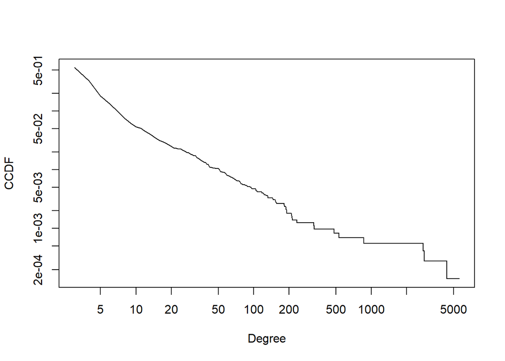

```r
# Cumulative distribution
ccdf = function(d) {
  n = length(d)
  max = max(d)
  p = rep(0, max)
  for (i in 1:length(p)) {
    p[i] = length(d[d >= i]) / n
  }
  return(p)
}

links = 3
p = ccdf(degree_dist)
plot(links:max(degree_dist), p[links:length(p)],
     log="xy", type = "l", xlab="Degree", ylab="CCDF")
```

```r
fit <- fit_power_law(degree_dist)
fit
```

```
## $continuous
## [1] FALSE
##
## $alpha
## [1] 2.059684
##
## $xmin
## [1] 9
##
## $logLik
## [1] -1812.691
##
## $KS.stat
## [1] 0.03272644
```

Questi risultati supportano fortemente l’ipotesi di una distribuzione power-law, caratteristica delle reti scale-free. Ciò implica la presenza di hub (nodi con grado elevato) che rendono la rete robusta a guasti casuali, ma vulnerabile a interventi mirati. Nel contesto del darkweb, questi hub potrebbero corrispondere a servizi critici (es. mercati o forum) da cui dipende gran parte dell’attività della rete.

Questo è coerente con la natura del darkweb, dove la mancanza di un motore di ricerca centralizzato porta all’esistenza di alcuni hub principali, spesso rappresentati da wiki contenenti link a molte altre pagine.

## Analisi dei nodi più connessi

```r
top_outdegree_nodes <- as_tibble(g, what = "nodes") %>%
  arrange(desc(out_degree)) %>%
  head(5)
print(top_outdegree_nodes)
```

```
## # A tibble: 5 × 8
##   Id             Label in_degree out_degree betweenness closeness eigen pagerank
##   <chr>          <lgl>     <dbl>      <dbl>       <dbl>     <dbl> <dbl>    <dbl>
## 1 directoryvi6p… NA            1       5582     138905. 0.000109  1     0.000114
## 2 visitorfi5kl7… NA           18       4367     958759. 0.0000959 0.886 0.000141
## 3 skunksworkedp… NA           41       2769     762903. 0.0000828 0.591 0.000311
## 4 cratedvnn5z57… NA            6       2758     169236. 0.0000803 0.570 0.000118
## 5 gxamjbnu7ukna… NA           13        848     134093. 0.0000490 0.154 0.000196
```

```r
in_edges <- edges %>%
  filter(Target == "directoryvi6plzm")

suspect_node <- as_tibble(g, what = "nodes") %>%
  filter(Id == in_edges$Source)
print(suspect_node)
```

```
## # A tibble: 1 × 8
##   Id             Label in_degree out_degree betweenness closeness eigen pagerank
##   <chr>          <lgl>     <dbl>      <dbl>       <dbl>     <dbl> <dbl>    <dbl>
## 1 visitorfi5kl7… NA           18       4367     958759. 0.0000959 0.886 0.000141
```

Un’osservazione interessante riguarda il nodo con più archi uscenti, il quale riceve un solo link in ingresso, proveniente dal secondo nodo con più archi uscenti. Questo suggerisce che `directoryvi6plzm` potrebbe o essere una directory non ufficiale o essere scarsamente riconosciuta dagli utenti del darkweb o avere una brutta reputazione.

# Group Analysis

Per individuare strutture interne alla rete, ho applicato diversi algoritmi di rilevamento delle comunità, selezionando quello con la modularità più elevata.

```r
# List of community detection methods in igraph
methods <- list(
  "Fast Greedy" = cluster_fast_greedy,
  "Leading Eigenvector" = cluster_leading_eigen,
  "Louvain" = cluster_louvain,
  "Walktrap" = cluster_walktrap,
  "Infomap" = cluster_infomap
)

# Compute modularity for each method
results <- data.frame(Method = character(), Modularity = numeric(), stringsAsFactors = FALSE)

for (method in names(methods)) {
  tryCatch({
    # Detect communities
    communities <- methods[[method]](as_undirected(g))

    # Compute modularity
    modularity_value <- modularity(communities)

    # Store the result
    results <- rbind(results, data.frame(Method = method, Modularity = modularity_value))
  }, error = function(e) {
    # Handle any errors (e.g., if a method is not applicable)
    cat("Error with method:", method, "\n")
  })
}

# Sort results by modularity in decreasing order
results <- results[order(-results$Modularity), ]

# Print the results
print(results)
```

```
##                Method Modularity
## 3             Louvain  0.3629604
## 5             Infomap  0.3397331
## 4            Walktrap  0.3315492
## 1         Fast Greedy  0.3093426
## 2 Leading Eigenvector  0.2098401
```

Il metodo Louvain si è rivelato il più efficace e ha identificato diverse comunità nella rete.

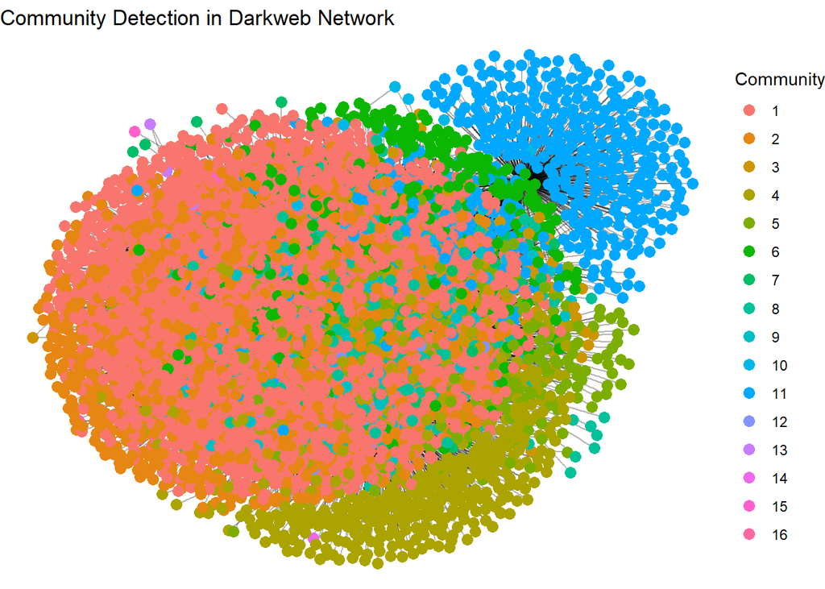

```r
communities <- cluster_louvain(as_undirected(g))

g <- g %>%
  mutate(Community = as.factor(communities$membership))

ggraph(g, layout = "lgl") +
  geom_edge_link(alpha = 0.3) +
  geom_node_point(aes(color = Community), size = 3) +
  theme_void() +
  labs(title = "Community Detection in Darkweb Network")
```

La visualizzazione del grafo con le comunità evidenzia la presenza di cluster di nodi densamente connessi, che potrebbero rappresentare specifiche categorie di siti o gruppi di attività correlate. Se un nodo fosse identificato come parte di attività illecite, sarebbe opportuno analizzare anche gli altri nodi della sua comunità.

# Global Analysis

```r
comp <- components(as.igraph(g))
cat("Numbero di componenti:", comp$no, "\n")
```

```
## Numbero di componenti: 1
```

```r
#giant_component <- induced_subgraph(as.igraph(g), which(comp$membership == which.max(comp$size)))
diameter_val <- diameter(g, directed = TRUE)
avg_path <- mean_distance(g, directed = TRUE)
cat("Diametro:", diameter_val, "\nAverage path length", avg_path, "\n")
```

```
## Diametro: 10
## Average path length 4.350535
```

```r
assortativity_value <- assortativity_degree(g, directed = TRUE)
cat("Assortativity (degree):", assortativity_value, "\n")
```

```
## Assortativity (degree): -0.3428776
```

Sebbene la distanza media tra i nodi del grafo (4,35) e il diametro (10) sembrino relativamente bassi, in precedenza è stato mostrato che la maggior parte dei nodi (circa il 87%) non ha archi uscenti, quindi questi valori sono fortemente influenzati dalla presenza di pochi nodi hub con un altissimo grado di connessione. L’assortatività negativa per grado indica che i nodi con pochi collegamenti tendono a nodi con tanti collegamenti e viceversa, caratteristica comune nelle reti scale-free.

## Percolazione e vulnerabilità della rete

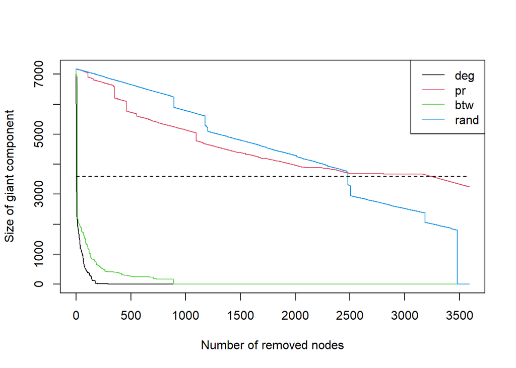

```r
# percolation removes nodes from a graph and computes
# the size of the giant connected component
# INPUT
# g: graph to percolate
# size: number of nodes to remove
# d: removal vector
# OUTPUT
# giant: a vector with sizes of giant components when nodes are removed
percolate = function(g, size, d) {

  giant = vector()

  # initial size of giant component
  c = components(g)
  giant[1] = max(c$csize)

  # find vital nodes
  names(d) = 1:length(d)
  d = sort(d, decreasing=TRUE)
  vital = as.integer(names(d[1:size]))

  # compute size of giant component after incremental removal
  for (i in 1:size) {
    c = components(delete_vertices(g, vital[1:i]))
    giant[i+1] = max(c$csize)
  }

  return(giant)

}

# resilience
size = vcount(g)/2
# random
rand = percolate(g, size, d = sample(V(g), size))
# degree
deg = percolate(g, size, d = degree(g))
# pagerank
pr = percolate(g, size, d = node_data$pagerank)
# betweenness
bet = percolate(g, size, d = node_data$betweenness)

plot(0:size, deg, type = "l", col=1,
     xlab="Number of removed nodes",
     ylab="Size of giant component")
lines(0:size, pr, col=2)
lines(0:size, bet, col=3)
lines(0:size, rand, col=4)
lines(0:size, rep(vcount(g)/2, size+1), lty=2)
legend(x = "topright",
       legend = c("deg", "pr", "btw", "rand"), lty = 1, col = 1:4)
```

L’analisi della percolazione ha confermato che la rete è molto vulnerabile ad attacchi mirati sugli hub, in particolare sulle pagine wiki che fungono da punti di accesso principali per la navigazione. Tuttavia, la rete è resistente ai guasti casuali, poiché la rimozione di nodi con pochi collegamenti non compromette significativamente la sua connettività.

Un aspetto interessante è che, anche in caso di attacco mirato alle pagine wiki, le altre pagine rimarrebbero comunque accessibili se si possiede il link diretto, evidenziando una certa resilienza del darkweb alla censura.

## Conclusioni

In questo studio ho analizzato una sottorete del darkweb ottenuta tramite crawling su onion.link, con l’obiettivo di comprendere le caratteristiche strutturali e dinamiche di questa rete complessa.

L’analisi locale ha evidenziato una distribuzione del grado fortemente sbilanciata, tipica di una rete scale-free. In particolare, la verifica della legge di potenza ha mostrato che la coda della distribuzione segue un comportamento power law (con esponente stimato pari a circa 2,06), confermando l’ipotesi che pochi nodi hub dominano la connettività complessiva mentre la maggior parte dei nodi risulta scarsamente connessa.

L’analisi di gruppo, effettuata mediante il metodo Louvain, ha permesso di identificare comunità ben definite all’interno della rete. Questi cluster, caratterizzati da una forte densità di collegamenti interni, potrebbero rappresentare specifiche categorie di siti o gruppi di attività correlate. Tale suddivisione evidenzia come, all’interno del darkweb, certi nodi (ad esempio, le pagine wiki) rivestano un ruolo centrale nella distribuzione delle informazioni e nella navigazione, fungendo da veri e propri punti di accesso.

L’approccio globale ha messo in luce ulteriori aspetti interessanti: una distanza media e un diametro relativamente bassi nonostante la maggior parte dei nodi non presenta archi uscenti. Inoltre, l’assortatività negativa per grado indica una tendenza per i nodi a collegarsi a nodi con un numero di connessioni molto diverso, rafforzando ulteriormente la natura scale-free della rete. Infine, l’analisi della percolazione ha evidenziato una notevole vulnerabilità della rete ad attacchi mirati sui nodi hub, soprattutto sulle pagine wiki, mentre la rete risulta robusta rispetto a guasti casuali. Questo aspetto suggerisce che, pur essendo la rete fragile sotto specifici tipi di attacco, essa mantiene una certa resilienza, in quanto la rimozione di nodi poco connessi non compromette significativamente l’accessibilità complessiva.

In sintesi, lo studio ha fornito una panoramica esaustiva della struttura del darkweb, mettendo in luce come la sua organizzazione, dominata da pochi nodi centrali e da comunità ben definite, comporti sia vantaggi (in termini di robustezza contro guasti casuali) che svantaggi (in termini di vulnerabilità a attacchi mirati).